# Lab 4 - Answers

- Show All Code
- Hide All Code
- View Source

Author

Jason Geller

Published

March 15, 2025

## Data

The data for this assignment comes from an online Ipsos survey that was conducted for the FiveThirtyEight article [“Why Many Americans Don’t Vote”](https://projects.fivethirtyeight.com/non-voters-poll-2020-election/). You can read more about the survey design and respondents in the README of the [GitHub repo](https://github.com/fivethirtyeight/data/tree/master/non-voters) for the data.

Respondents were asked a variety of questions about their political beliefs, thoughts on multiple issues, and voting behavior. We will focus on using the demographic variables and someone’s party identification to understand whether a person is a probable voter.

The variables we’ll focus on were (definitions from the codebook in data set GitHub repo):

- `ppage`: Age of respondent
- `educ`: Highest educational attainment category.
- `race`: Race of respondent, census categories. Note: all categories except Hispanic were non-Hispanic.
- `gender`: Gender of respondent
- `income_cat`: Household income category of respondent
- `Q30`: Response to the question “Generally speaking, do you think of yourself as a…”
  - 1: Republican
  - 2: Democrat
  - 3: Independent
  - 4: Another party, please specify
  - 5: No preference
  - -1: No response
- `voter_category`: past voting behavior:
  - **always**: respondent voted in all or all-but-one of the elections they were eligible in
  - **sporadic**: respondent voted in at least two, but fewer than all-but-one of the elections they were eligible in
  - **rarely/never**: respondent voted in 0 or 1 of the elections they were eligible in

You can read in the data directly from the GitHub repo:

```r
library(nnet)
library(car)
library(tidyverse)
library(emmeans)
library(ggeffects)
library(knitr)
library(patchwork)
library(broom)
library(parameters)
library(easystats)
```

```r
voter_data <- read_csv("https://raw.githubusercontent.com/fivethirtyeight/data/master/non-voters/nonvoters_data.csv")
```

# Lab

- The variable `Q30` contains the respondent’s political party identification. Make a new variable that simplifies `Q30` into four categories: “Democrat”, “Republican”, “Independent”, “Other” (“Other” also includes respondents who did not answer the question).

  ```r
  voter_data <- voter_data %>%
    mutate(pol_ident_new = case_when(
      Q30==1 ~ "Rep",
      Q30==2 ~ "Dem",
      Q30==3 ~ "Indep",
      TRUE ~ "Other"
    ))
  ```

- The variable `voter_category` identifies the respondent’s past voter behavior. Relevel the variable to make rarely/never the baseline level, followed by sporadic, then always

  ```r
  voter_data$voter_category <- factor(voter_data$voter_category, levels =c("rarely/never", "sporadic", "always"))
  ```

```r
# center var
voter_data$ppage <- datawizard::center(voter_data$ppage)
```

- In the [FiveThirtyEight article](https://projects.fivethirtyeight.com/non-voters-poll-2020-election/), the authors include visualizations of the relationship between the voter category and demographic variables such as race, age, education, etc. Select two demographic variables. For each variable, try to replicate the visualizations and interpret the plot to describe its relationship with voter category. Have fun with it: https://www.mikelee.co/posts/2020-02-08-recreate-fivethirtyeight-chicklet-stacked-bar-chart-in-ggplot2.

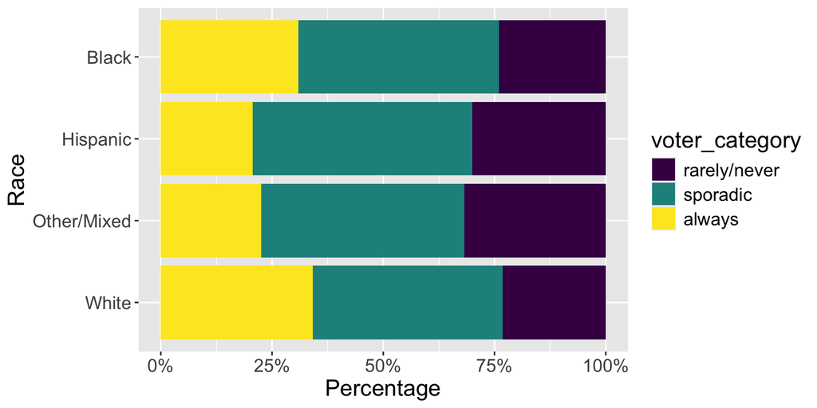

  ```r
   # library
  library(ggplot2)
  library(viridis)
  library(cowplot)


  voter_data$race <- factor(voter_data$race, levels =c("Black", "Hispanic", "Other/Mixed", "White"))

  p_race <- ggplot(data = voter_data, aes(x = fct_rev(race), fill = voter_category)) +
    geom_bar(position = "fill") +
      labs(x="Race", y="Percentage") +
    theme(text = element_text(size = 16)) +
     scale_x_discrete(limits = rev(levels("race")))+
    scale_fill_viridis(discrete = TRUE) +
    scale_y_continuous(labels = scales::percent_format(accuracy = 1)) +
    coord_flip()

  p_race
  ```

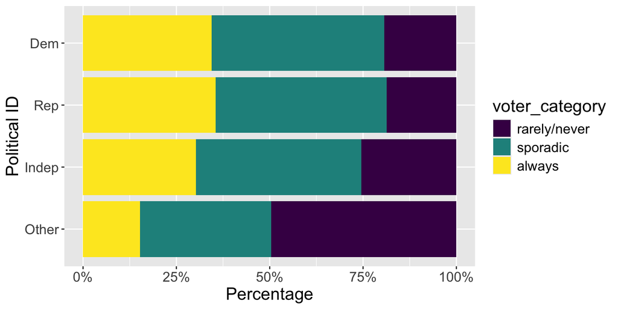

  ```r
  voter_data <- voter_data %>%
    mutate(pol =  fct_relevel(pol_ident_new,"Dem", "Rep", "Indep", "Other"))


  p_id <- ggplot(voter_data, aes(x = fct_rev(pol), fill = voter_category)) +
    geom_bar(position = "fill") +
      labs(x="Political ID", y="Percentage") +
    theme(text = element_text(size = 16)) +
    scale_fill_viridis(discrete = TRUE) +
    scale_y_continuous(labels = scales::percent_format(accuracy = 1)) +
    coord_flip()

  p_id
  ```

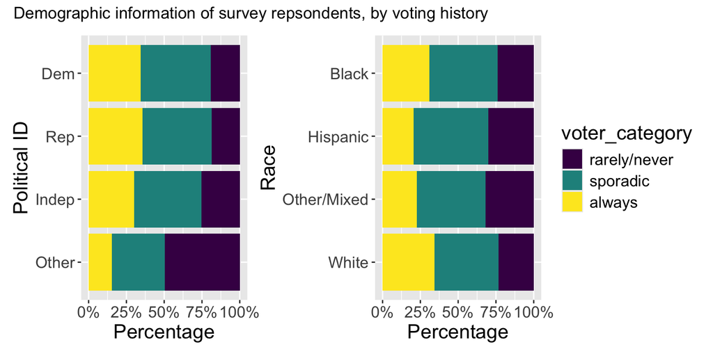

  ```r
  library(patchwork)
  p_id+ p_race + plot_layout(guides = "collect") + plot_annotation(title = 'Demographic information of survey repsondents, by voting history')
  ```

- Fit a model using mean-centered age, race, gender, income, and education to predict voter category. Show the code used to fit the model, but do **not** display the model output.

```r
    library(nnet)

    mm <- multinom(voter_category~ ppage + race + gender+ income_cat + educ, data=voter_data)

    model_parameters(mm)
```

- *Should party identification be added to the model?*

```r
mm_red<- multinom(voter_category~ ppage + race + gender+ income_cat + educ, data=voter_data)

mm_full <- multinom(voter_category~ ppage + race + gender+ income_cat + educ + pol, data=voter_data)

    anova(mm_red, mm_full)
```

[output not shown]

```
> Yes. It should be included.
```

**Use the model you select for the remainder of the assignment**.